# Homework 1- IE360

Filiz Günal - IE360 - SPRING 2020

22 04 2020

## INTRODUCTION

In last 5 years, the exchange rates have been rapidly changed. It had important effects on Turkey’s economy. The main aim of the analysis is to observe the relationship of the change of exchange rates between the Turkey’s economy in last 5 years. The analysis is conducted with dollar selling and euro selling levels as exchange rates, and level of seaonally adjusted capacity utilization rate of manufacturing industry as well as unemployment rate and search volume of job advertisement on Google from Turkey. The data are token both from Electronic Data Delivery System and Google.

## APPROACH

There were some NA values in the data. However, these NA values were belonged to last 3 months. Due to pandemic, these data would not contribute to the analysis. Therefore, NA values are omitted from the data. Also, the data is filtered in order to obtain the last 5 years’ data. The reason behind analysing last 5 years’ data is minimizing the effects of other than exchange rate on the change of level of seaonally adjusted capacity utilization rate of manufacturing industry as well as unemployment rate and search volume of job advertisement on Google from Turkey. Besides, these data are merged and an extended time series object is created. These steps are given in the code below.

```r
require(readxl) # to read excel input
require(data.table) # to use data.table functionalities
```

```r
require(corrplot)
require(anytime)
require(xts)
data_path = '/Users/Asus/Downloads/EVDS.xlsx'

# read the data
dat = read_excel(data_path, sheet='EVDS', n_max=152)

# transform the data
evds = data.table(dat)

# display the structure of the data
str(evds)
```

```
## Classes 'data.table' and 'data.frame':   151 obs. of  5 variables:
##  $ Tarih          : chr  "2007-10" "2007-11" "2007-12" "2008-01" ...
##  $ TP DK USD S YTL: num  1.2 1.19 1.18 1.18 1.19 ...
##  $ TP DK EUR S YTL: num  1.71 1.75 1.72 1.73 1.76 ...
##  $ TP KKO MA      : num  81.9 81.8 80.8 80.9 81.1 80.3 80.8 80.9 81.5 80.7 ...
##  $ TP TIG07       : num  9.2 9.5 9.9 10.4 10.8 10.1 9.1 8.4 8.7 9.1 ...
##  - attr(*, ".internal.selfref")=<externalptr>
```

```r
# rename the data
rename_evds = c("date", "dollar_selling", "euro_selling", "cpty_ute_mfg", "unemp_rate")
setnames(evds, names(evds), rename_evds)

csv_path = '/Users/Asus/Downloads/multiTimeline.csv'

# import data
trends=fread(csv_path, skip = 1)

# rename the data
rename_gt = c("date", "sv_jobs_turkey")
names(trends) = rename_gt

# display the head of the data
head(trends, 5)
```

```
##       date sv_jobs_turkey
## 1: 2007-10             52
## 2: 2007-11             45
## 3: 2007-12             46
## 4: 2008-01             46
## 5: 2008-02             60
```

```r
# merge the data
merged_data = merge(evds, trends, fill=NA, join = "left")

# check missing points
sum(is.na(merged_data))
```

```
## [1] 4
```

```r
colSums(is.na(merged_data))
```

```
##           date dollar_selling   euro_selling   cpty_ute_mfg     unemp_rate
##              0              0              0              1              3
## sv_jobs_turkey
##              0
```

```r
rowSums(is.na(merged_data))
```

```
##   [1] 0 0 0 0 0 0 0 0 0 0 0 0 0 0 0 0 0 0 0 0 0 0 0 0 0 0 0 0 0 0 0 0 0 0 0 0 0
##  [38] 0 0 0 0 0 0 0 0 0 0 0 0 0 0 0 0 0 0 0 0 0 0 0 0 0 0 0 0 0 0 0 0 0 0 0 0 0
##  [75] 0 0 0 0 0 0 0 0 0 0 0 0 0 0 0 0 0 0 0 0 0 0 0 0 0 0 0 0 0 0 0 0 0 0 0 0 0
## [112] 0 0 0 0 0 0 0 0 0 0 0 0 0 0 0 0 0 0 0 0 0 0 0 0 0 0 0 0 0 0 0 0 0 0 0 0 0
## [149] 1 1 2
```

```r
tail(merged_data)
```

```
##       date dollar_selling euro_selling cpty_ute_mfg unemp_rate sv_jobs_turkey
## 1: 2019-11       5.741548     6.351286         76.7       13.3             79
## 2: 2019-12       5.848150     6.492559         76.9       13.7             81
## 3: 2020-01       5.928827     6.586905         75.8       13.8             75
## 4: 2020-02       6.055370     6.605785         76.6         NA             72
## 5: 2020-03       6.325805     7.001341         76.2         NA             50
## 6: 2020-04       6.759779     7.364550           NA         NA             29
```

```r
# it is found that missing values belong to last 3 months
# due to pandemic, last three months' data will not provide
# desired contribution to the analysis. Therefore, it is wisely
# to omit rows with NA values.
data_omit = na.omit(merged_data)
str(data_omit)
```

```
## Classes 'data.table' and 'data.frame':   148 obs. of  6 variables:
##  $ date          : chr  "2007-10" "2007-11" "2007-12" "2008-01" ...
##  $ dollar_selling: num  1.2 1.19 1.18 1.18 1.19 ...
##  $ euro_selling  : num  1.71 1.75 1.72 1.73 1.76 ...
##  $ cpty_ute_mfg  : num  81.9 81.8 80.8 80.9 81.1 80.3 80.8 80.9 81.5 80.7 ...
##  $ unemp_rate    : num  9.2 9.5 9.9 10.4 10.8 10.1 9.1 8.4 8.7 9.1 ...
##  $ sv_jobs_turkey: int  52 45 46 46 60 50 45 45 58 60 ...
##  - attr(*, ".internal.selfref")=<externalptr>
##  - attr(*, "sorted")= chr "date"
```

```r
# create date object
dates = data_omit$date
date_object = anydate(dates)
dates_format = as.Date(date_object,"%Y-%m")
str(dates_format)
```

```
##  Date[1:148], format: "2007-10-01" "2007-11-01" "2007-12-01" "2008-01-01" "2008-02-01" ...
```

```r
data_omit$date=dates_format
data_omit$sv_jobs_turkey=as.numeric(data_omit$sv_jobs_turkey)
str(data_omit)
```

```
## Classes 'data.table' and 'data.frame':   148 obs. of  6 variables:
##  $ date          : Date, format: "2007-10-01" "2007-11-01" ...
##  $ dollar_selling: num  1.2 1.19 1.18 1.18 1.19 ...
##  $ euro_selling  : num  1.71 1.75 1.72 1.73 1.76 ...
##  $ cpty_ute_mfg  : num  81.9 81.8 80.8 80.9 81.1 80.3 80.8 80.9 81.5 80.7 ...
##  $ unemp_rate    : num  9.2 9.5 9.9 10.4 10.8 10.1 9.1 8.4 8.7 9.1 ...
##  $ sv_jobs_turkey: num  52 45 46 46 60 50 45 45 58 60 ...
##  - attr(*, ".internal.selfref")=<externalptr>
```

```r
subset_data_omit = subset(data_omit, data_omit$date>= "2015-01-01")
str(subset_data_omit)
```

```
## Classes 'data.table' and 'data.frame':   61 obs. of  6 variables:
##  $ date          : Date, format: "2015-01-01" "2015-02-01" ...
##  $ dollar_selling: num  2.33 2.46 2.59 2.65 2.65 ...
##  $ euro_selling  : num  2.72 2.79 2.81 2.86 2.96 ...
##  $ cpty_ute_mfg  : num  74.7 75.2 75.4 77.3 77.5 77.4 78 76.5 77.6 76.9 ...
##  $ unemp_rate    : num  11.3 11.2 10.6 9.6 9.3 9.6 9.8 10.1 10.3 10.5 ...
##  $ sv_jobs_turkey: num  51 52 45 46 46 54 58 62 58 63 ...
##  - attr(*, ".internal.selfref")=<externalptr>
```

```r
# create the xts object
time_series = xts(subset_data_omit, order.by = subset_data_omit$date)
is.xts(time_series)
```

```
## [1] TRUE
```

```r
str(time_series)
```

```
## An 'xts' object on 2015-01-01/2020-01-01 containing:
##   Data: chr [1:61, 1:6] "2015-01-01" "2015-02-01" "2015-03-01" "2015-04-01" ...
##  - attr(*, "dimnames")=List of 2
##   ..$ : NULL
##   ..$ : chr [1:6] "date" "dollar_selling" "euro_selling" "cpty_ute_mfg" ...
##   Indexed by objects of class: [Date] TZ: UTC
##   xts Attributes:
##  NULL
```

After, the interrelationship between data is observed with the code given below.

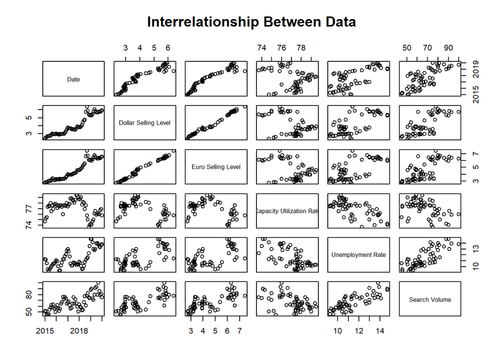

```
              Figure 1: Interrelationship Between Data
```

```r
# observe the relationship between data
pairs(subset_data_omit, main = "Interrelationship Between Data", labels = c("Date", "Dollar Selling Level","Euro Selling Level","Capacity Utilization Rate","Unemployment Rate","Search Volume"))
```

It is seen that dollar selling level and euro selling level are highly correlated. Therefore, the correlations between dollar selling level and data related to economic indicators, which are level of seaonally adjusted capacity utilization rate of manufacturing industry as well as unemployment rate and search volume of job advertisement on Google from Turkey, will be similar to the correlationa between euro selling level and data related to economic indicators. The change of exchange rates over time and related codes are shown in the figure below.

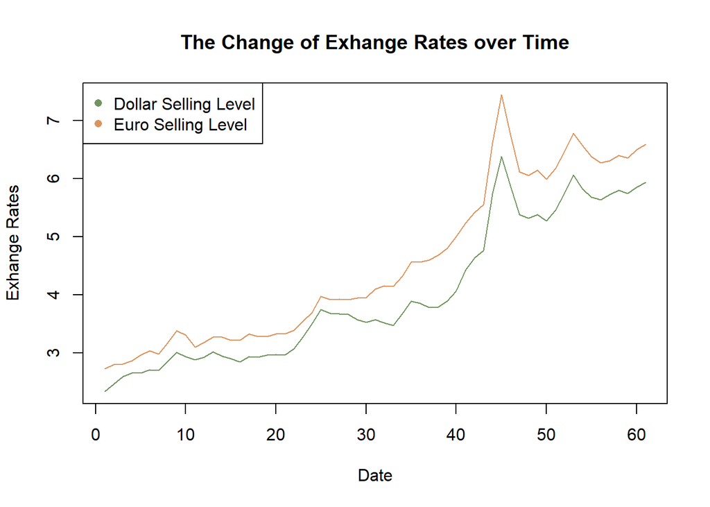

```
             Figure 2: The Change of Exhange Rates over Time
```

```r
# plot the change of exchange rates over time
ts.plot(cbind(time_series$dollar_selling,time_series$euro_selling), main = "The Change of Exhange Rates over Time", xlab="Date", ylab="Exhange Rates", col= c(rgb(0.2,0.4,0.1,0.7),rgb(0.8,0.4,0.1,0.7)))
legend("topleft", legend= c("Dollar Selling Level", "Euro Selling Level"), col = c(rgb(0.2,0.4,0.1,0.7),rgb(0.8,0.4,0.1,0.7)), pch=16)
```

From the figure, it can be said that the dollar selling level and euro selling level show similar patterns and they have significantly increased in last 5 years. For further analysis, these relationships are seperately investigated.

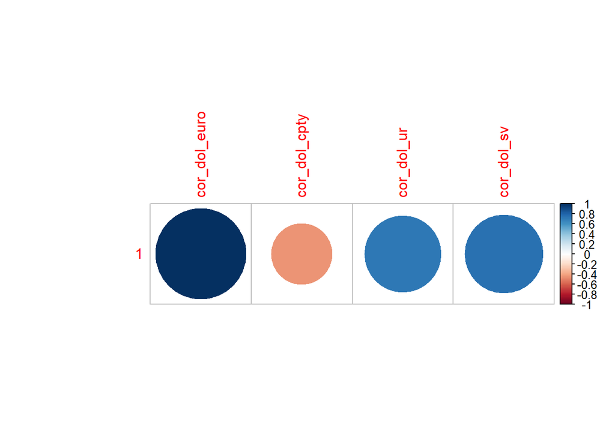

```
    Figure 3: Correlation of Dollar Selling Level with Other Elements in Data
```

```r
# correlation calculations
# correlation between dollar selling and other elements
cor_dol_euro = cor(subset_data_omit$dollar_selling,subset_data_omit$euro_selling)
cor_dol_cpty = cor(subset_data_omit$dollar_selling,subset_data_omit$cpty_ute_mfg)
cor_dol_ur = cor(subset_data_omit$dollar_selling,subset_data_omit$unemp_rate)
cor_dol_sv = cor(subset_data_omit$dollar_selling,subset_data_omit$sv_jobs_turkey)
corr_dol = cbind(cor_dol_euro,cor_dol_cpty,cor_dol_ur,cor_dol_sv)
corrplot(corr_dol,main="")
```

The figure shows that level of dollar selling and euro selling has strongly correlation with one another, which is equal to 0.993. On the other hand, level of seaonally adjusted capacity utilization rate of manufacturing industry and level of dollar selling is negatively correlated. The correlation factor is -0.448, so they have moderately negative correlation. Also, level of dollar selling level has positive correlation with unemployment rate and the search volume of job advertisement. The correlation coefficient between level of dollar selling and unemployment rate is 0.710, whereas the correlation coefficient between level of dollar selling and the search volume of job advertisement is 0.745. The small difference between these two correlation coefficients is reasonable. Firstly, there are people who have a job yet looking for a new job. Another reason may be about the TUIK’s definition of unemployment. Nevertheless, the coefficients are quite similar.

The same analysis is conducted for level of euro selling and plotted coefficient constants as well as related codes are shown in the figure below.

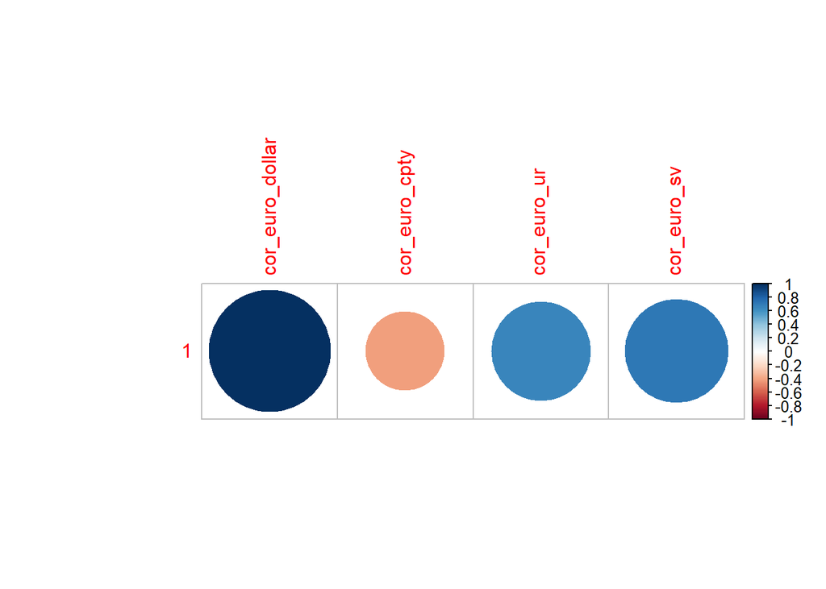

```
   Figure 4: Correlation of Euro Selling Level with Other Elements in Data
```

```r
# correlation between euro selling and other elements
cor_euro_dollar = cor(subset_data_omit$dollar_selling,subset_data_omit$euro_selling)
cor_euro_cpty = cor(subset_data_omit$euro_selling,subset_data_omit$cpty_ute_mfg)
cor_euro_ur = cor(subset_data_omit$euro_selling,subset_data_omit$unemp_rate)
cor_euro_sv = cor(subset_data_omit$euro_selling,subset_data_omit$sv_jobs_turkey)
corr_euro = cbind(cor_euro_dollar,cor_euro_cpty,cor_euro_ur,cor_euro_sv)
corrplot(corr_euro,  main="")
```

So far, it is observed that exchange rates have moderately strong positive correlation with the unemployment rate and the search volume of job advertisement. However, the cofficients of correlation between the capacity utilization rate and exchange rates are negative and relatively small.

It is important to check whether the data related to economic indicators is indeed related with one another or not. The correlation between the capacity utilization rate and the other two economic indicators are investigated below.

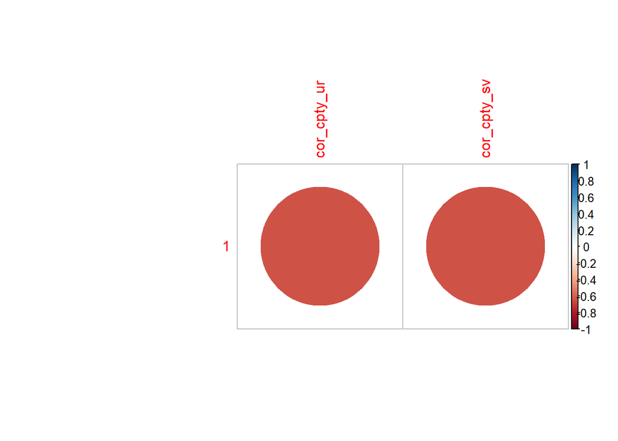

[output not shown]

```r
# check the relationship between capacity utilization rate of
# manufacturing industry and unemployment rate as well as
# search volume of job advertisement on Google from Turkey
cor_cpty_ur = cor(subset_data_omit$cpty_ute_mfg,subset_data_omit$unemp_rate)
cor_cpty_sv = cor(subset_data_omit$cpty_ute_mfg,subset_data_omit$unemp_rate)
corr_cpty = cbind(cor_cpty_ur, cor_cpty_sv)
corrplot(corr_cpty, main="")
```

Lastly, the relationship between unemployment rate and the search volume is investigated below.

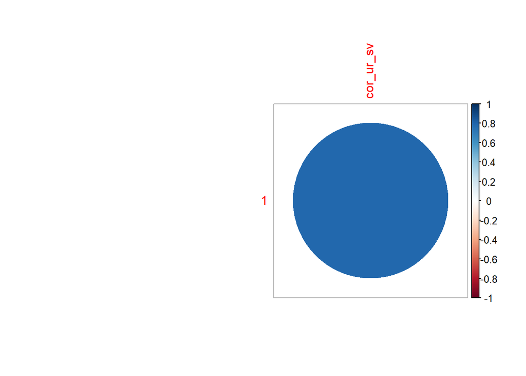

```
Figure 6: Correlation Between the Unemployment Rate and the Search Volume of Job Advertisement
```

```r
# lastly, check the relationship between unemployment rate and
# search volume of job advertisement on Google from Turkey
cor_ur_sv = cor(subset_data_omit$sv_jobs_turkey,subset_data_omit$unemp_rate)
corr_ur=cbind(cor_ur_sv)
corrplot(corr_ur, main="")
```

The figure illustrates a positive correlation between the unemployment rate and the search volume, which is expected. The correlation coefficient is equal to 0.788.

## CONCLUSION

The purpose of the analysis is to observe the relationship between the change of exchange rates and the Turkey’s economy in last 5 years. It is found that exchange rates have moderately strong positive correlation with the unemployment rate and the search volume of job advertisement but negative and relatively small correlation with the capacity utilization rate. Also, the TUIK’s definition of unemployment as well as people who have a job but looking for a new job may have affected the correlation in a negative way.

## REFERENCES

[1] “Electronic Online Delivery System” [Online], Available at https://evds2.tcmb.gov.tr/index.php (Accessed in April, 2020)

[2] “Google Trends Search for Job Advertisement” [Online], Available at https://trends.google.com/trends/explore?q=i%C5%9F%20ilan%C4%B1&geo=TR (Accessed in April, 2020)

Reference for code: https://github.com/BU-IE-360/spring20-gunalfiliz/blob/master/Homework%201-%20IE360.R